# Problem Sheet 2

Theory of Inference

Dom Hutchinson

```r
set.seed(16111998)
```

# Question 1

## Part a)

```r
head(cars);
```

|  | speed | dist |
| --- | --- | --- |
| 1 | 4 | 2 |
| 2 | 4 | 10 |
| 3 | 7 | 4 |
| 4 | 7 | 22 |
| 5 | 8 | 16 |
| 6 | 9 | 10 |

## Part b)

```r
cars.model<-lm(dist~speed+I(speed^2)-1,data=cars) # response vars ~ expected predictors form # I() ensures ^2 is interpretted arithmetically & not as a model parameter
cars.model
```

```
Call:
lm(formula = dist ~ speed + I(speed^2) - 1, data = cars)

Coefficients:
     speed  I(speed^2)
   1.23903     0.09014
```

$\hat\beta_1=1.23903\ \&\ \hat\beta_2=0.0901388$.

## Part c)

```r
summary(cars.model)
```

```
Call:
lm(formula = dist ~ speed + I(speed^2) - 1, data = cars)

Residuals:
    Min      1Q  Median      3Q     Max
-28.836  -9.071  -3.152   4.570  44.986

Coefficients:
           Estimate Std. Error t value Pr(>|t|)
speed       1.23903    0.55997   2.213  0.03171 *
I(speed^2)  0.09014    0.02939   3.067  0.00355 **
---
Signif. codes:  0 ‘***’ 0.001 ‘**’ 0.01 ‘*’ 0.05 ‘.’ 0.1 ‘ ’ 1

Residual standard error: 15.02 on 48 degrees of freedom
Multiple R-squared:  0.9133,    Adjusted R-squared:  0.9097
F-statistic: 252.8 on 2 and 48 DF,  p-value: < 2.2e-16
```

```r
coefs<-summary(cars.model)$coefficients
coefs["speed","Estimate"]
```

```
[1] 1.23903
```

$\hat\beta_1=1.23903,\ \hat\beta_2=0.0901388,\ \hat\sigma_{\hat\beta_1}=0.5599707\ \&\ \hat\sigma_{\hat\beta_2}=0.0293892$.

## Pard d)

```r
head(model.matrix(cars.model))
```

```
  speed I(speed^2)
1     4         16
2     4         16
3     7         49
4     7         49
5     8         64
6     9         81
```

## Part e)

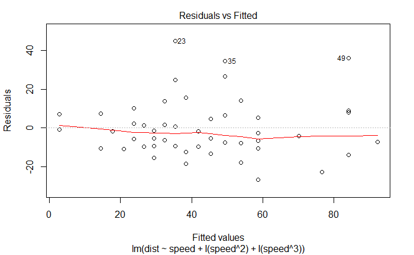

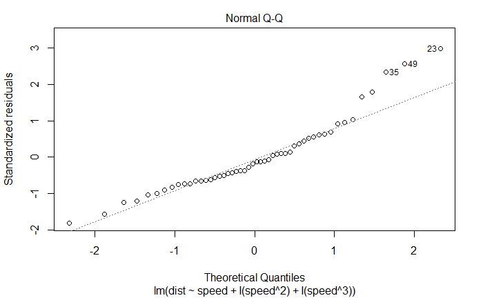

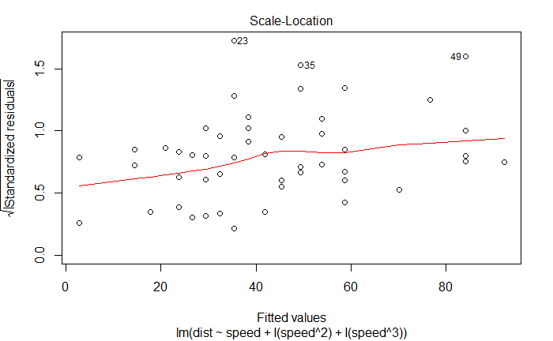

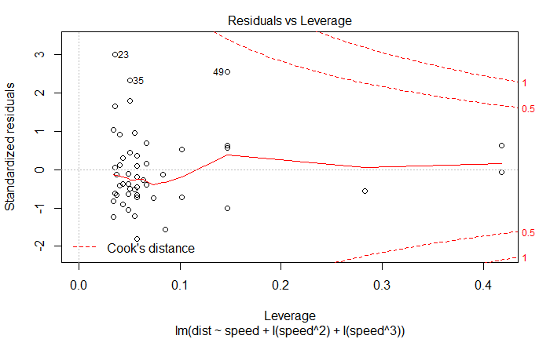

```r
cm1<-lm(dist~speed+I(speed^2)+I(speed^3),data=cars)
plot(cm1)
```

## Part f)

```r
summary(cm1)
```

```
Call:
lm(formula = dist ~ speed + I(speed^2) + I(speed^3), data = cars)

Residuals:
    Min      1Q  Median      3Q     Max
-26.670  -9.601  -2.231   7.075  44.691

Coefficients:
             Estimate Std. Error t value Pr(>|t|)
(Intercept) -19.50505   28.40530  -0.687    0.496
speed         6.80111    6.80113   1.000    0.323
I(speed^2)   -0.34966    0.49988  -0.699    0.488
I(speed^3)    0.01025    0.01130   0.907    0.369

Residual standard error: 15.2 on 46 degrees of freedom
Multiple R-squared:  0.6732,    Adjusted R-squared:  0.6519
F-statistic: 31.58 on 3 and 46 DF,  p-value: 3.074e-11
```

```r
cm2<-lm(dist~speed+I(speed^2)+I(speed^3)-1,data=cars)
summary(cm2)
```

```
Call:
lm(formula = dist ~ speed + I(speed^2) + I(speed^3) - 1, data = cars)

Residuals:
    Min      1Q  Median      3Q     Max
-27.741  -8.755  -4.049   5.435  45.345

Coefficients:
            Estimate Std. Error t value Pr(>|t|)
speed       2.299945   1.802672   1.276    0.208
I(speed^2) -0.038399   0.209557  -0.183    0.855
I(speed^3)  0.003638   0.005871   0.620    0.539

Residual standard error: 15.12 on 47 degrees of freedom
Multiple R-squared:  0.914, Adjusted R-squared:  0.9085
F-statistic: 166.5 on 3 and 47 DF,  p-value: < 2.2e-16
```

```r
cm3<-lm(dist~speed+I(speed^3)-1,data=cars)
summary(cm3)
```

```
Call:
lm(formula = dist ~ speed + I(speed^3) - 1, data = cars)

Residuals:
    Min      1Q  Median      3Q     Max
-28.084  -9.058  -4.116   5.062  45.289

Coefficients:
            Estimate Std. Error t value Pr(>|t|)
speed      1.9751471  0.3250123   6.077 1.91e-07 ***
I(speed^3) 0.0025727  0.0008204   3.136  0.00292 **
---
Signif. codes:  0 ‘***’ 0.001 ‘**’ 0.01 ‘*’ 0.05 ‘.’ 0.1 ‘ ’ 1

Residual standard error: 14.97 on 48 degrees of freedom
Multiple R-squared:  0.9139,    Adjusted R-squared:  0.9103
F-statistic: 254.8 on 2 and 48 DF,  p-value: < 2.2e-16
```

```r
coefs3<-summary(cm3)$coefficients
```

By dropping the least significant term until all terms have $p$-valeus less than 0.05 we get the suggestion that the following is the best model
$$\mathtt{dist}_i=\beta_1\mathtt{speed}_i+\beta_2\mathtt{speed}_i^3+\varepsilon_i$$
where $\hat\beta_1=1.9751471\ \&\ \hat\beta_2=0.0025727$.

## Part g)

$\mathtt{time}_i=\frac{\mathtt{dist}_i}{\beta_1\mathtt{speed}_i}$.
We obtain a $95\%$ confidence interval for $\beta_1$ using $\hat\beta_1\pm t_{n-p}(.975)\hat\sigma_{\hat\beta_1}$.
In this scenario $n=50,\ p=2,\ \hat\beta_1=1.9751471\ \&\ \hat\sigma_{\hat\beta_1}=0.3250123$. Note that $t_{48}(.975)=2.0106348$.
Producing the following confidence interval for $\beta_1$.
$$[1.3216661,2.6286281]$$
If we now take the sample means $\mathtt{speed}$ & $\mathtt{dist}$ of we can produce a confidence interval for $\mathtt{time}$ (accounting for speed being in miles/hour & distance being in feet).
$$\frac{1}{5280\times60\times60}\left[\frac{1.3216661\times42.98}{15.4},\frac{2.6286281\times42.98}{15.4}\right]=\left[1.9405776\times 10^{-7},3.8595654\times 10^{-7}\right]$$
The final confidence interval is for the reaction speed in seconds.
# Question 2

## Part a)

```r
n<-100                # Sample size
beta.true<-c(.5,1,10) # True parameter values
ct<-qt(.975,n-3)      # Critical points for CIs
cp<-beta.true*0       # Coverage probability array
n.rep<-1000           # Number of replicates to run
for (i in 1:n.rep) {
  x<-runif(n)                                                      # simulated covariate
  mu<-beta.true[1]+beta.true[2]*x+beta.true[3]*x^2
  y<-mu+rnorm(n)*.3                                                # Simulated data
  m1<-lm(y~x+I(x^2))                                               # fit model to this replicate
  b<-coef(m1)                                                      # extract parameter estimates
  sig.b<-diag(vcov(m1))^.5
  cp<-cp+as.numeric(b-ct*sig.b<=beta.true & b+ct*sig.b>=beta.true) # Count whether coefficients in interval
}
cp/n.rep
```

[output not shown]

## Part b)

```r
n<-100                # Sample size
beta.true<-c(.5,1,10) # True parameter values
ct<-qt(.975,n-3)      # Critical points for CIs
cp<-beta.true*0       # Coverage probability array
n.rep<-1000           # Number of replicates to run
for (i in 1:n.rep) {
  x<-runif(n)                                                      # simulated covariate
  mu<-beta.true[1]+beta.true[2]*x+beta.true[3]*x^2
  y<-rpois(n,mu)                                                # Simulated data
  m1<-lm(y~x+I(x^2))                                               # fit model to this replicate
  b<-coef(m1)                                                      # extract parameter estimates
  sig.b<-diag(vcov(m1))^.5
  cp<-cp+as.numeric(b-ct*sig.b<=beta.true & b+ct*sig.b>=beta.true) # Count whether coefficients in interval
}
cp/n.rep
```

[output not shown]

## Part c)

```r
# Generate data
n<-50;
x<-runif(n)
mu<-beta.true[1]+beta.true[2]*x+beta.true[3]*x^2
y<-rpois(n,mu)

# Bootstrap
cp<-beta.true*0
n.rep<-1000
for (i in 1:n.rep) {
  bi<-sample(1:n,n,replace=TRUE)
  yb<-y[bi]
  xb<-x[bi]
  m1<-lm(yb~xb+I(xb^2))
  b<-coef(m1)
  sig.b<-diag(vcov(m1))^.5
  cp<-cp+as.numeric(b-ct*sig.b<=beta.true & b+ct*sig.b>=beta.true) # Count whether coefficients in interval
}
cp/n.rep
```

[output not shown]